# HW2_Q1

The “HW2_ who_talks_to_whom.xlsx” contains all the messages (both sent and received) from all kinds of communications between the 2017/18 MSc Business Analytics class, for a particular week. After transforming this file into a dataset and creating the network, many important insights were gained.

Before the start of writing any codes, it is important to load the appropriate libraries at the top.

```python
# Import networkx library and rename it as nx.
import networkx as nx

# Adding support for high-performance, easy-to-use data structures and data analysis tools
import pandas as pd

# Adding support for large, multi-dimensional arrays and matrices.
import numpy as np

import matplotlib.pyplot as plt
import operator
import sys
```

```python
# Put the path of the folder that contains the data file.
place_holder = "./"

# The file name
excelfile = "HW2_who_talks_to_whom.xlsx"
```

Next, we have to read the Excel file and store it with variables 'sent' and 'received'.

```python
# Read the sheet 'Sent'
sent = pd.read_excel(excelfile, sheet_name="Sent", usecols = "B:CD")

# Read the sheet 'Received'
received = pd.read_excel(excelfile, sheet_name="Received", usecols = "B:CD")

# Make NaN the values with "-"
sent.replace({'-': np.nan}, inplace = True)
received.replace({'-': np.nan}, inplace = True)


dG = nx.DiGraph()

# Reset index start from 1, instead of 0
sent.index = np.arange(1, len(sent) + 1)
received.index = np.arange(1, len(received) + 1)

totalLen = len(sent) if len(sent) > len(received) else len(sent)

# Pivot a level of the column labels, and get a series of corresponding
# values with a single level of column labels
sent = sent.stack().reset_index()
sent.columns = ['from','to','talks']

received = received.stack().reset_index()
# change the level so that it is 'to-from' instead of 'from-to'
received = received[['level_1','level_0',0]]
received.columns = ['from','to','talks']
```

Note that the initial dataset has many problems and it is not correct. Also, some duplicate values may occur and result in 4 edges between the nodes (2 in talks dataset and 2 in received dataset).

```python
# Concatenate the 2 dataframes
total = pd.concat([sent,received], axis = 0, join = 'outer')
total = total [['from','to','talks']]

# Change the title to 'nodeA' and 'nodeB'
total.columns = ['nodeA','nodeB','talks']
```

After loading the data and putting it in a correct format, we can start creating the graph using Networkx.

```python
# Create a direct graph based on the dataframe format
dG = nx.from_pandas_edgelist(total, 'nodeA', 'nodeB', 'talks', create_using = nx.DiGraph())

# Transform node type to string, as it was shown as float
mapping = {x: str(x) for x in range(1, totalLen + 1)}
dG = nx.relabel_nodes(dG, mapping)

undG = nx.from_pandas_edgelist(total, 'nodeA', 'nodeB', 'talks', create_using = nx.Graph())
undG = nx.relabel_nodes(undG, mapping)
# nx.write_weighted_edgelist(dG, sys.stdout)
```

Now, we can get some useful information out of the graph.

We can find the in-degree and out-degree for each node to understand who sent or received most number of messages.

```python
d_in = dict(dG.in_degree())
d_out = dict(dG.out_degree())

sortedin = sorted(d_in.items(), key = operator.itemgetter(1), reverse = True)
sortedout = sorted(d_out.items(), key = operator.itemgetter(1), reverse = True)

l1 =list()
l2 = list()

for i in range (0,4):
     l1.append(sortedin[i][0])
     l2.append(sortedout[i][0])

print("The 4 people(nodes) who sent the most messages to any other person in the class are:" + " " + str(l2))
print("The 4 people(nodes) who received the most messages from any other person in the class are:" + " " + str(l1))
```

```
The 4 people(nodes) who sent the most messages to any other person in the class are: ['32', '22', '62', '37']
The 4 people(nodes) who received the most messages from any other person in the class are: ['32', '22', '62', '37']
```

We can also the different centralities from the graph.

Let's say we want to get the betweenness centrality. This tells us how many times a node is in the middle of any shortest path between other nodes or put it simply, in how many paths between two other nodes (u and v for instance), this node belongs.

```python
d = dict(nx.betweenness_centrality(dG, weight = 'talks'))
sortedbet = sorted(d.items(), key = operator.itemgetter(1), reverse = True)
print("The person(node) with the highest betweeness centrality is:" + " " + str(sortedbet[0][0]))
```

```
The person(node) with the highest betweeness centrality is: 32
```

Next we measure the closeness centrality. This is a local metric of centrality that gives a score to each node based on how close this node is to all other nodes in the network.

```python
# closeness centrality
d = dict(nx.closeness_centrality(dG))
sortedclos = sorted(d.items(), key = operator.itemgetter(1), reverse = True)
print("The person(node) with the highest closeness centrality value is:" + " " + str(sortedclos[0][0]))
```

```
The person(node) with the highest closeness centrality value is: 32
```

We also measure the eigenvector centrality. Eigenvector centrality is a global metric that measures the importance of each node which is proportional to the sum of neighbors’ importance.

```python
# eigenvector centrality
d = dict(nx.eigenvector_centrality_numpy(dG, weight = 'talks'))
sortedeigen = sorted(d.items(), key = operator.itemgetter(1), reverse = True)
print ("The person(node) with the highest eigenvector centrality value is:" + " " + str(sortedeigen[0][0]))
```

```
The person(node) with the highest eigenvector centrality value is: 73
```

Last but not least, clustering coefficient and average clustering coefficient are also calculated. These measures show how many neighbors of a node communicate each other.

```python
# clustering coefficient
dcc = dict(nx.clustering(undG, weight = 'talks'))
sortedcc = sorted(dcc.items(), key = operator.itemgetter(1), reverse = True)
print ("The person(node) with the highest clustering coefficient value is:" + " " + str(sortedcc[0][0]))

average_cc = nx.average_clustering(undG, weight = 'talks')
print("The average clustering coefficient of the graph is:" + " "+ str(average_cc))
```

```
The person(node) with the highest clustering coefficient value is: 59
The average clustering coefficient of the graph is: 0.020350925042028276
```

Finally, we plot the graph based on the edge information. Note that this is just one of the examples how the graph can be ploted. Other solution can also be accepted.

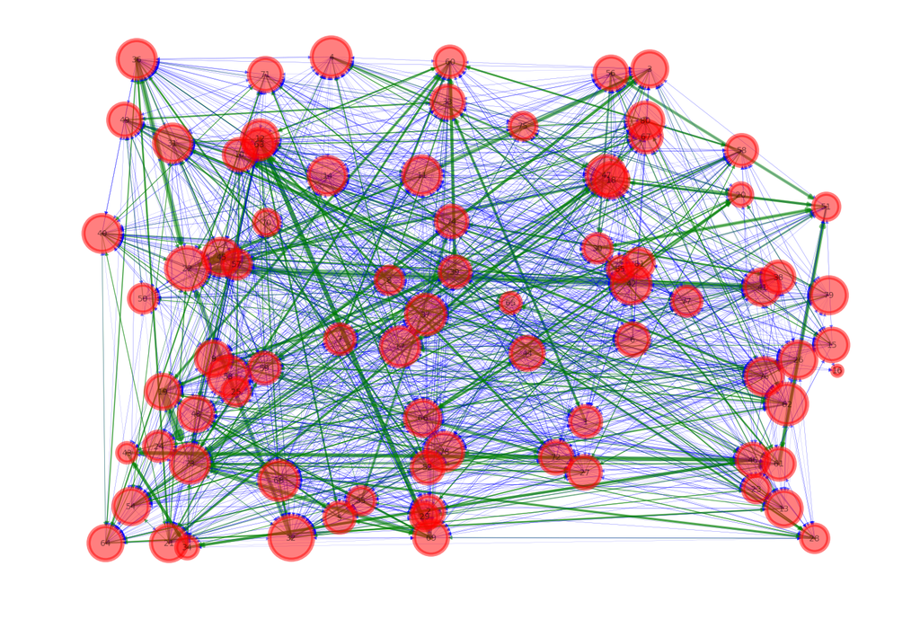

```python
for u,v in dG.edges():
    # green edge if they communicated more than 5 times
    if dG[u][v]['talks'] > 5 :
        dG[u][v]['color'] = 'green'
    # blue otherwise
    else:
        dG[u][v]['color'] = 'blue'

plt.figure(figsize = (15,10), dpi = 100)

# Nodes with the output edges having larger value will be bigger,
# Edge with a larger value for 'talks' will also be larger
nx.draw(dG, pos = nx.random_layout(dG), with_labels = True, node_color = 'red',
        node_size = [v * 50 for v in d_out.values()],
        width = [dG[u][v]['talks'] / 10 for u,v in dG.edges()],
        edge_color = [dG[u][v]['color'] for u,v in dG.edges()],
        linewidths = 5, alpha = 0.5, font_size = 10)
```